# Sesión 6: Aplicaciones y Extensiones

Agosto 15, 2015

## Agenda

- Presentaciones proyectos (1era parte)
- Repaso regresión lineal y aplicaciones en R
- Aplicaciones de la estadística en la innovación social y la política pública
- Conclusiones generales del curso

## Regresión: aplicaciones en R

## ENUT: Tiempo de estudio en casa y edad

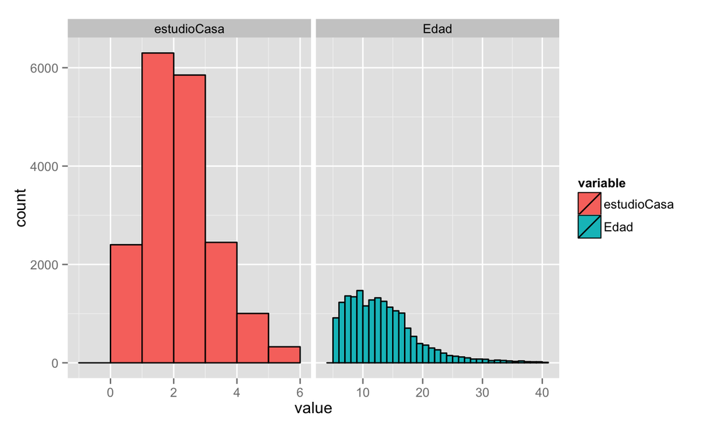

## ENUT: Tiempo de estudio en casa y Establecimiento

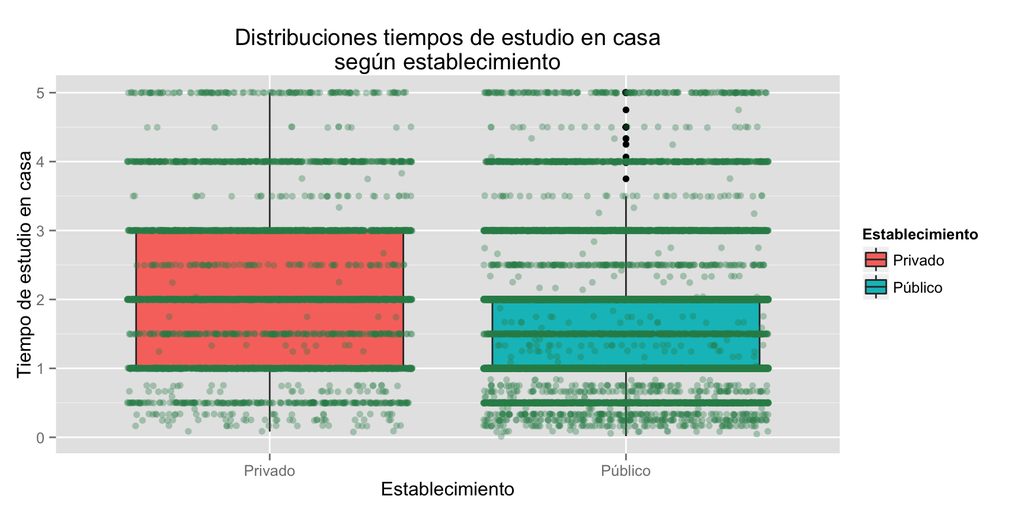

## ENUT: Tiempo de estudio en casa y Nivel Educativo

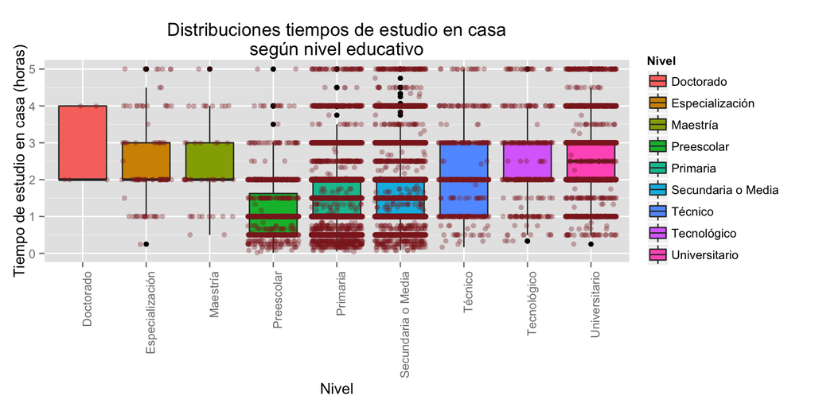

## ENUT: Tiempo de estudio en casa y Día de Referencia

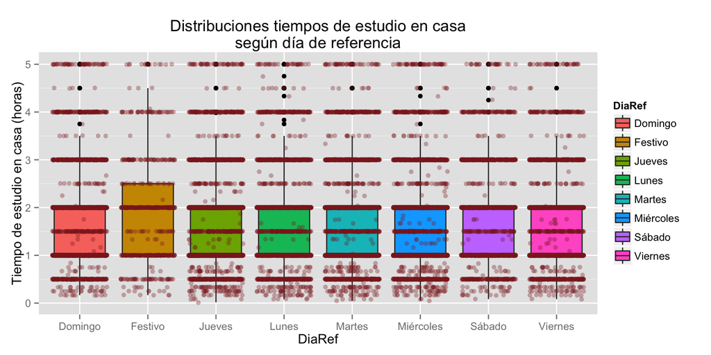

## ENUT: Tiempo de estudio en casa y Región

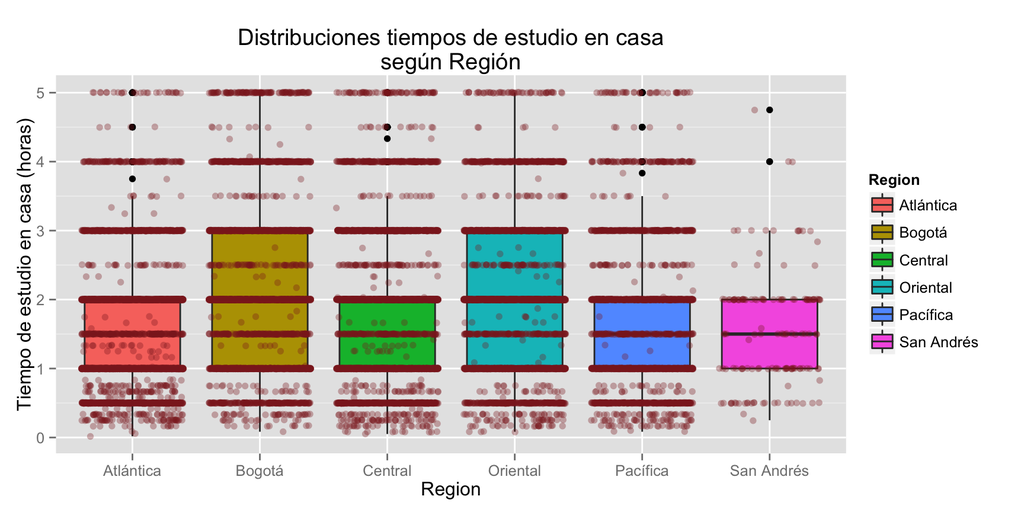

## Regresión múltivariada en R

```r
fit <- lm(estudioCasa ~ ., data=casa)
fit$coefficients
```

```
            (Intercept)                    Edad  EstablecimientoPúblico
            2.503026365             0.005567892            -0.160364677
   NivelEspecialización           NivelMaestría         NivelPreescolar
           -0.283893146            -0.403777088            -1.300639935
          NivelPrimaria NivelSecundaria o Media            NivelTécnico
           -0.980146636            -0.698620438            -0.509208582
       NivelTecnológico      NivelUniversitario         GeneroMasculino
           -0.239321186            -0.070630196            -0.049586571
           RegionBogotá           RegionCentral          RegionOriental
            0.358752977             0.244247029             0.346480313
         RegionPacífica        RegionSan Andrés           DiaRefFestivo
            0.056214785             0.061947685             0.003496072
           DiaRefJueves             DiaRefLunes            DiaRefMartes
           -0.098894109            -0.084211971            -0.088482321
        DiaRefMiércoles            DiaRefSábado           DiaRefViernes
           -0.104514278            -0.017218109            -0.135859447
```

## Predicciones usando el modelo `fit`

- Supongamos que tenemos un estudiante en Bogotá, del género masculino, que atiende a la Universidad Nacional. ¿Cuanto tiempo de estudio dedica este estudiante desde su casa durante los sábados y domingos?
- Recordemos que la edad no tiene un impacto relevante por lo que simplemente asumiremos que el estudiante tiene 22 años
- Usamos la función `predict()`, que permite además generar un intervalo de confianza para la predicción

| Día | fit | lwr | upr |
| --- | --- | --- | --- |
| Sábado | 2.686 | 0.7977 | 4.575 |
| Domingo | 2.704 | 0.815 | 4.592 |

## Aplicaciones de la estadística

## Toma de decisiones bajo incertidumbre

- **OR (Management Science)**: campo de estudio que emplea computadores, estadística y matemáticas para resolver problemas de negocios
- Emplea modelos matemáticos para ayudar en la toma de decisiones
- Define objetivo, variables que se pueden controlar, restricciones y optimiza la función objetivo (maximizar beneficios o minimizar costos)
- Muchas veces existe incertidumbre alrededor de los componentes de un modelo de este estilo
- Por lo que se puede emplear simulación para definir el modelo matemático

## Pasos

- Definir objetivo
- Definir variables de decisión (controlables)
- Definir restricciones
- Definir modelo matemático
- Asignar distribuciones (formas) y probabilidades
- Simular
- Optimizar

## Simulación y optimización*

### *manual

- Si seleccionamos los tres proyectos, la inversión total sería de 1600, por lo que estaríamos por encima de nuestro presupuesto
- El presupuesto es una restricción que no permite, en este caso, seleccionar más de dos proyectos a la vez
- Nuestra variable de decisión es entonces qué proyecto(s) seleccionar. ¿Uno o dos? y ¿Cuál(es)?
- Objetivo: Maximizar el beneficio esperado
- El espacio de decisión es pequeño (6), por lo que es posible maximizar "manualmente"
- Sólo es cuestión de definir supuestos (distribuciones) y **SIMULAR** el beneficio esperado

## ¿Cuál sería el beneficio esperado si pudieramos optar por los tres proyectos al tiempo?

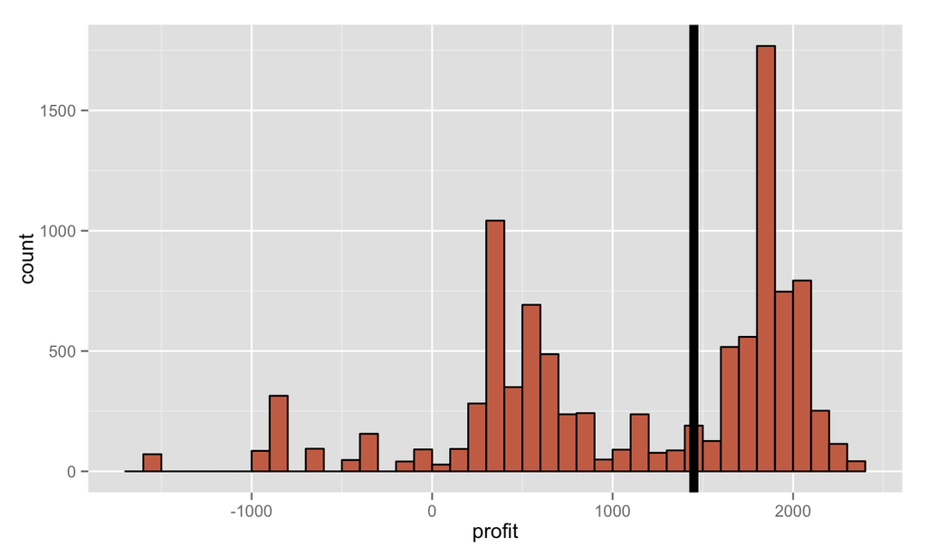

## Selección óptima de proyectos

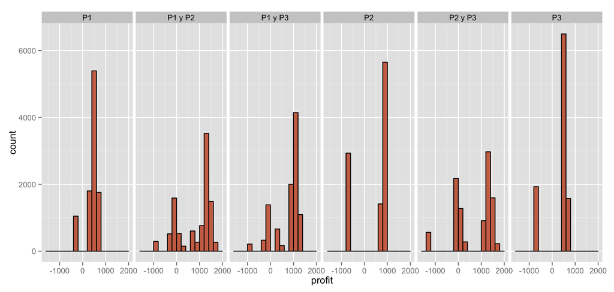

## Selección óptima de proyectos: Estadísticas descriptivas

| alternativa | mean.profit | sd.profit |
| --- | --- | --- |
| P1 | 420.8 | 246.3 |
| P1 y P2 | 810 | 717.2 |
| P1 y P3 | 713.2 | 550.7 |
| P2 | 389.2 | 676.7 |
| P2 y P3 | 681.5 | 835.7 |
| P3 | 292.3 | 491.1 |

## Riesgo y Retorno

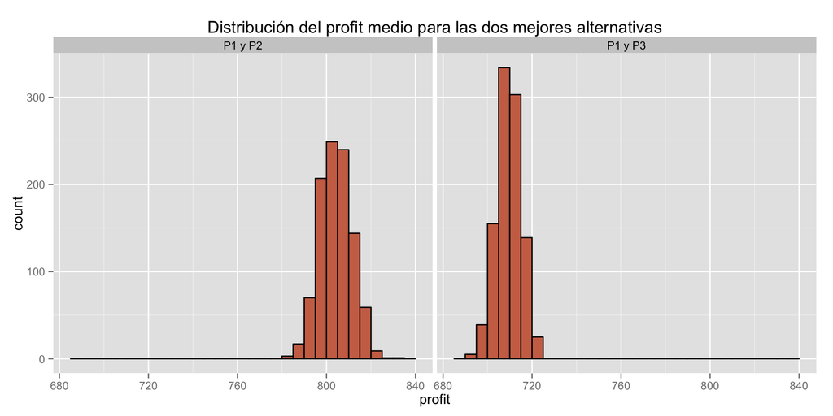

## Intervalos de confianza para ambas medias (95%)

```
[1] "Alternativa P1 y P2: Profit esperado"
```

```
[1] 803.7731 804.6691
attr(,"conf.level")
[1] 0.95
```

```
[1] "Alternativa P1 y P3: Profit esperado"
```

```
[1] 709.1396 709.8127
attr(,"conf.level")
[1] 0.95
```

## Formas de refinar el análisis

- Mejorar supuestos de distribuciones: triangular en lugar de discreta para el caso de mejor-peor-probable-escenario
- Análisis de sensibilidad
- Costo de no ejecutar presupuesto

## Otras aplicaciones en toma de decisiones

- Teoría de filas (Queuing Theory)
- Gestión de proyectos (cuellos de botella)
- Modelado y optimización de procesos (BPM)

## Herramientas de Inteligencia Artificial para las políticas públicas y la innovación social

- Creciente flujo de información en diversos dominios
- Información compleja (no estructurada)
- Mayor importancia en la solución de problemas críticos
- Enfermedades
- Crimen
- Terrorismo
- Pobreza
- Poder computacional & métodos escalables de análisis de datos

## Análisis de grandes conjuntos de datos

- Machine Learning: Sistemas que mejoran su desempeño con la experiencia (aprendiendo de datos)
- Artificial Intelligence: Ciencia que estudia formas para automatizar comportamientos complejos como el conocimiento, el aprendizaje, la solución de problemas, y la toma de decisiones
- Data Mining: Aplicación de algoritmos para la extracción de información útil a partir de grandes conjuntos de datos

## Aplicación en el dominio social y de PP

- Generación de conocimiento accionable a partir de información no estructurada
- Predecir y explicar
- Modelar estructuras complejas
- Detectar patrones

## Tres paradigmas de la IA

- Predicción (rule-based, case-based, model-based): Predecir variables de interés (elecciones, tasas de mortalidad)
- Modelaje (relaciones probabilisticas): Modelaje de sistemas complejos como ciudades o enfermedades para la gestión óptima
- Detección (anomalías, patrones): Muy usado en detección de contrabando, lavado de activos, evasión de impuestos, epidemias, ataques terroristas

## Aplicación para Colombia: Dinámica laboral para recién graduados

- Patiño y Basto (2010): Recently Graduated Labor Market Dynamics in Colombia
- Base de datos del observatorio laboral (2001-2007)
- Algoritmos: C4.5 (Arbol de Clasificación) y Naive Bayes
- Clasificar: éxito en la búsqueda de empleo
- Origen privado: mejor predictor (nivel académico)
- Origen público: mejor predictor (región)

## Estudiar un PhD reduce probabilidades de éxito en la búsqueda de trabajo

[figure not shown]

## En cuanto a areas de conocimiento, ingenierías y economía y administración incrementan probabilidades de éxito

[figure not shown]

## Otra aplicación: Comercio Internacional

- Patiño y Quintero (2011): Economic Growth Outbreaks: Is Connectedness a Good Predictor?
- Visualización de redes de comercio internacional
- ¿Emerge el crecimiento económico a partir de comunidades de comercio?
- Análisis de redes sociales (de comercio en este caso)
- Algoritmos de segmentación
- "We find evidence of correlation between trade clusters and growth outbreaks"

## Red de comercio (cluster 2)

[figure not shown]

## Crecimiento promedio PIB - clusters

[figure not shown]